# Self-Driving Car Engineer Nanodegree

## Project: Build a Traffic Sign Recognition Classifier

## Completed by Gabe Johnson

This project uses a convolutional neural network to classify images of German traffic signs.

First, import libraries

```python
import random
import numpy as np
import matplotlib.pyplot as plt
import cv2
from sklearn.utils import shuffle
import tensorflow as tf
from tensorflow.contrib.layers import flatten
import pickle
%matplotlib inline
```

## Step 1: Load The Data

```python
# Load pickled data

training_file = 'traffic-signs-data/train.p'
validation_file= 'traffic-signs-data/valid.p'
testing_file = 'traffic-signs-data/test.p'

with open(training_file, mode='rb') as f:
    train = pickle.load(f)
with open(validation_file, mode='rb') as f:
    valid = pickle.load(f)
with open(testing_file, mode='rb') as f:
    test = pickle.load(f)

X_train_loaded, y_train = train['features'], train['labels']
X_valid_loaded, y_valid = valid['features'], valid['labels']
X_test_loaded, y_test = test['features'], test['labels']
```

## Step 2: Dataset Summary & Exploration

This cell provides some useful numbers to help understand the characteristics of the data

```python
# Number of training examples
n_train = X_train_loaded.shape[0]

# Number of validation examples
n_validation = X_valid_loaded.shape[0]

# Number of testing examples.
n_test = X_test_loaded.shape[0]

# Shape of an traffic sign image
image_shape = X_train_loaded.shape[1:]

# Number of unique classes/labels there are in the dataset.
n_classes = max([max(y_train),max(y_valid),max(y_test)])+1

print("Number of training examples =", n_train)
print("Number of validation examples =", n_validation)
print("Number of testing examples =", n_test)
print("Image data shape =", image_shape)
print("Number of classes =", n_classes)
```

```
Number of training examples = 34799
Number of validation examples = 4410
Number of testing examples = 12630
Image data shape = (32, 32, 3)
Number of classes = 43
```

As an example, here is one image from the training set and the number of its label which corresponds to a type of traffic sign.

```
2
```

```
True
```

[figure not shown]

```python
index = random.randint(0, len(X_train_loaded))
image = X_train_loaded[index].squeeze()

plt.figure(figsize=(3,3))
plt.imshow(image)
print(y_train[index])

cv2.imwrite('ReferencePictures/example.jpg',cv2.cvtColor(image,cv2.COLOR_BGR2RGB))
```

Here I plot a histogram of the label data in the training set to see how many samples we have to train on for each label. Below that I display the histogram's bin numbers and the number of occurances of each label.

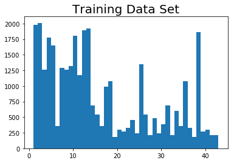

```
[  1.   2.   3.   4.   5.   6.   7.   8.   9.  10.  11.  12.  13.  14.  15.
  16.  17.  18.  19.  20.  21.  22.  23.  24.  25.  26.  27.  28.  29.  30.
  31.  32.  33.  34.  35.  36.  37.  38.  39.  40.  41.  42.  43.]
[ 1980.  2010.  1260.  1770.  1650.   360.  1290.  1260.  1320.  1800.
  1170.  1890.  1920.   690.   540.   360.   990.  1080.   180.   300.
   270.   330.   450.   240.  1350.   540.   210.   480.   240.   390.
   690.   210.   599.   360.  1080.   330.   180.  1860.   270.   300.
   210.   210.]
```

```python
n, bins, patches = plt.hist(y_train,42,(1,43))
plt.title('Training Data Set', fontsize=20)
plt.show()
print(bins)
print(n)
```

The histogram above shows us that there are some traffic sign types where we have a very small sample size to train on. This means the model won't have a good chance to learn them. So make more of them...

```python
# first, define the transformation matrix (M) for the affine transformation
offset = 3
startpoints = np.array([[offset,offset],[offset,31-offset],[31-offset,offset]]).astype(np.float32)
endpoints = np.array([[1,1],[1,31],[31,1]]).astype(np.float32)
M = cv2.getAffineTransform(startpoints,endpoints)

for i in range(1,n_classes):#+1):
    signindices = np.where(y_train==i)
    if (len(signindices[0]) < 500):
        #create a list of zeros to hold the added images. Using a numpy array gives errors from opencv operations later.
        addsigns = [[[ [0 for _ in range(3) ] for _ in range(32)] for _ in range(32)] for _ in range(len(signindices[0]))]
        addclassifier = []
        for j in range(len(signindices[0])):
            addsigns[j] = cv2.warpAffine(X_train_loaded[signindices[0][j]], M, (32,32))
            addclassifier.append(i)
        #X_train_loaded.append(addsigns)
        #y_train.append(addclassifier)
        X_train_loaded = np.append(X_train_loaded, addsigns, axis=0)
        y_train = np.append(y_train, addclassifier)

# Recalculate the number of training examples
n_train = X_train_loaded.shape[0]

# Check for mismatch between number of images and number of labels
assert X_train_loaded.shape[0] == y_train.shape[0]
assert X_valid_loaded.shape[0] == y_valid.shape[0]
assert X_test_loaded.shape[0] == y_test.shape[0]
```

Here I show an example image before duplication/enlargement. This is not necessarily one of the scarce sign types.

```
True
```

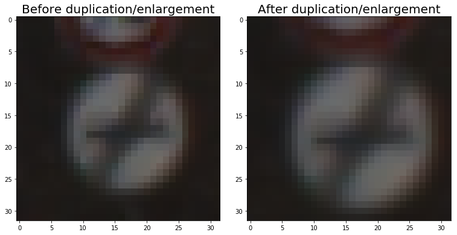

```python
trans = cv2.warpAffine(X_train_loaded[0],M,(32,32))
f, (ax1, ax2) = plt.subplots(1, 2, figsize=(10, 10))
f.tight_layout()
ax1.imshow(X_train_loaded[0])
ax1.set_title("Before duplication/enlargement", fontsize=20)
ax2.imshow(trans)
ax2.set_title("After duplication/enlargement", fontsize=20)
plt.subplots_adjust(left=0., right=1, top=0.9, bottom=0.)

cv2.imwrite('ReferencePictures/original.jpg',X_train_loaded[0])
cv2.imwrite('ReferencePictures/enlarged.jpg',trans)
```

Now look at the histogram of the training set again. Notice that there are more samples to learn from.

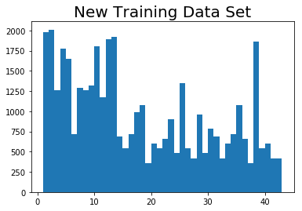

```python
n, bins, patches = plt.hist(y_train,42,(1,43))
plt.title('New Training Data Set', fontsize=20)
plt.show()
```

For reference, here is a histogram of the validation data set

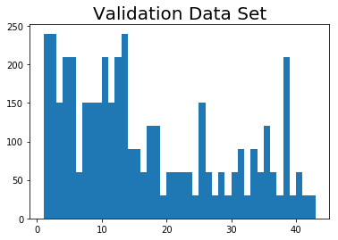

```python
n, bins, patches = plt.hist(y_valid,42, (1,43))
plt.title('Validation Data Set', fontsize=20)
plt.show()
```

For reference, here is a histogram of the test data set

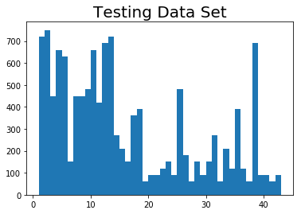

```python
n, bins, patches = plt.hist(y_test,42, (1,43))
plt.title('Testing Data Set', fontsize=20)
plt.show()
```

## Step 3: Design and Test a Model Architecture

### Pre-process the data

Here I define several funtions that can be used to pre-process the data. This includes choosing a colorspace and normalizing the data between -1 and +1. It is interesting to see the difference in training the model depending on which function is used.

This function keeps all three channels of the RGB images. I found that it works the best of all these functions

```python
def RGBnorm(X):
    rgbnorm = np.empty([X.shape[0],image_shape[0],image_shape[1],image_shape[2]],dtype=float)
    for n in range(0,X.shape[0]):
        for h in range(0,image_shape[0]):
            for w in range(0,image_shape[1]):
                rgbnorm[n][h][w][0] = (X[n][h][w][0]-128)/128
                rgbnorm[n][h][w][1] = (X[n][h][w][1]-128)/128
                rgbnorm[n][h][w][2] = (X[n][h][w][2]-128)/128

    return rgbnorm
```

This function converts the images to HSV color space.

```python
def HSVnorm(X):
    hsvnorm = np.empty([X.shape[0],image_shape[0],image_shape[1],image_shape[2]],dtype=float)
    for n in range(0,X.shape[0]):
        hsvx= cv2.cvtColor(X[n],cv2.COLOR_RGB2HSV)
        hsvnormx = hsvx.astype(float)
        for h in range(0,image_shape[0]):
            for w in range(0,image_shape[1]):
                hsvnormx[h][w][0] = ((hsvx[h][w][0]-90)/90)
                hsvnormx[h][w][1]= ((hsvx[h][w][1]-128)/128)
                hsvnormx[h][w][2]= ((hsvx[h][w][2]-128)/128)
        hsvnorm[n] = hsvnormx
    return hsvnorm
```

This function converts the images to a single channel grayscale image

```python
def GRYnorm(X):
    graynorm = np.empty([X.shape[0],image_shape[0],image_shape[1],1],dtype=float)
    for n in range(0,X.shape[0]):
        grayx = cv2.cvtColor(X[n],cv2.COLOR_RGB2GRAY)
        for h in range(0,grayx.shape[0]):
            for w in range(0,grayx.shape[1]):
                graynorm[n][h][w][0]= ((grayx[h][w]-128)/128)
    return graynorm
```

This function returns only the Hue channel of the HSV color space for the images.

```python
def HUEnorm(X):
    huenorm = np.empty([X.shape[0],image_shape[0],image_shape[1],1],dtype=float)
    for n in range(0,X.shape[0]):
        hsvx= cv2.cvtColor(X[n],cv2.COLOR_RGB2HSV)
        for h in range(0,hsvx.shape[0]):
            for w in range(0,hsvx.shape[1]):
                huenorm[n][h][w][0]= ((hsvx[h][w][0]-90)/90)
    return huenorm
```

Use this cell to choose which pre-processing funtion to use and specify the number of channels

```python
X_train = RGBnorm(X_train_loaded)
X_valid = RGBnorm(X_valid_loaded)
chan=3 #number of channels of the input images
```

### Model Architecture

Specify the number or epochs, batch size, and learning rate to use when training the model

```python
EPOCHS = 11
BATCH_SIZE = 275
rate = 0.001 #learning rate
```

Create some placeholders that I can later feed with the data sets and labels

```python
keep_prob = tf.placeholder(tf.float32) #probability to keep units in dropout
x = tf.placeholder(tf.float32, (None, 32, 32, chan))
y = tf.placeholder(tf.int32, (None))
one_hot_y = tf.one_hot(y, 43)
```

The model is defined here. It is loosely based on the LeNet architecture. The comments give additional details.

```python
def Model(x):
    # Arguments used for tf.truncated_normal,
    #randomly defines variables for the weights and biases for each layer
    mu = 0.0
    sigma = 0.1

    #Layer 1: Convolutional. Input = 32x32x3. Output = 28x28x18.
    #W1 size: think of the size of the kernel to pass over the image
    #(width of filter, height of filter, input channels, output channels)
    #using tf.truncated_normal() to keep from introducing values more than two standard deviations away from mean
    W1 = tf.Variable(tf.truncated_normal(shape = (5, 5, chan, 18), mean = mu, stddev = sigma))
    #b1 size: number of output channels
    b1 = tf.Variable(tf.zeros(18))
    #Set the stride for each dimension (batch_size, height, width, depth)  batch_size and depth are generally 1
    strides = [1, 1, 1, 1]
    padding = 'VALID'
    CL1 = tf.nn.conv2d(x, W1, strides, padding)
    CL1 = tf.nn.bias_add(CL1, b1)

    #Activation Function.
    AL1 = tf.nn.relu(CL1)

    #Max Pooling. Input = 28x28x18. Output = 14x14x18.
    #kernel size for max pooling filter (batch_size, height, width, depth)
    ksize = [1, 2, 2, 1]
    strides = [1, 2, 2, 1]
    padding = 'SAME'
    PL1 = tf.nn.max_pool(AL1, ksize, strides, padding)

    #Layer 2: Convolutional. Output = 10x10x32.
    W2 = tf.Variable(tf.truncated_normal(shape = (5, 5, 18, 32), mean = mu, stddev = sigma))
    b2 = tf.Variable(tf.zeros(32))
    strides = [1, 1, 1, 1]
    padding = 'VALID'
    CL2 = tf.nn.conv2d(PL1, W2, strides, padding)
    CL2 = tf.nn.bias_add(CL2, b2)

    #Activation Function.
    AL2 = tf.nn.relu(CL2)

    #Dropout
    DL2 = tf.nn.dropout(AL2, keep_prob)

    #Max Pooling. Input = 10x10x32. Output = 5x5x32.
    ksize = [1, 2, 2, 1]
    strides = [1, 2, 2, 1]
    padding = 'SAME'
    PL2 = tf.nn.max_pool(DL2, ksize, strides, padding)

    #Flatten. Input = 5x5x32. Output = 800.
    FL2 = flatten(PL2)

    #Layer 3: Fully Connected. Input = 800. Output = 120.
    W3 = tf.Variable(tf.truncated_normal(shape = (800, 120), mean = mu, stddev = sigma))
    b3 = tf.Variable(tf.zeros(120))
    CL3 = tf.matmul(FL2,W3)
    CL3 = tf.add(CL3,b3)

    #Activation Function.
    AL3 = tf.nn.relu(CL3)

    #Dropout
    DL3 = tf.nn.dropout(AL3, keep_prob)

    # Layer 4: Fully Connected. Input = 120. Output = 84.
    W4 = tf.Variable(tf.truncated_normal(shape = (120, 84), mean = mu, stddev = sigma))
    b4 = tf.Variable(tf.zeros(84))
    CL4 = tf.matmul(DL3,W4)
    CL4 = tf.add(CL4,b4)


    #Activation Function.
    AL4 = tf.nn.relu(CL4)

    #Dropout
    DL4 = tf.nn.dropout(AL4, keep_prob)

    # Layer 5: Fully Connected. Input = 84. Output = 43.
    W5 = tf.Variable(tf.truncated_normal(shape = (84, 43), mean = mu, stddev = sigma))
    b5 = tf.Variable(tf.zeros(43))
    CL5 = tf.matmul(DL4,W5)
    CL5 = tf.add(CL5,b5)

    logits = CL5

    return logits, AL1, AL2
```

- Call the model
- Compare the model results to the ground-truth labels
- Calculate the error
- Optimize the model's coefficients, incrementing by the learning rate
- Minimize the error

```python
#predictions for the data
logits, AL1, AL2 = Model(x)
#measures the difference between the ground-truth labels to the results of the model
cross_entropy = tf.nn.softmax_cross_entropy_with_logits(labels=one_hot_y, logits=logits)
#gets the average of the differences from all the training images
loss_operation = tf.reduce_mean(cross_entropy)
#minimize the loss function
optimizer = tf.train.AdamOptimizer(learning_rate = rate)
#run the minimize function on the optimizer which uses back propogation to update the network
#and minimize our training loss
training_operation = optimizer.minimize(loss_operation)
```

Determine the accuracy of the model predictions

```python
#compare logit prediction to the one-hot encoded ground truth label
correct_prediction = tf.equal(tf.argmax(logits, 1), tf.argmax(one_hot_y, 1))
#calculate overall accuracy by averaging individual accuracies
accuracy_operation = tf.reduce_mean(tf.cast(correct_prediction, tf.float32))
saver = tf.train.Saver()

#batch data, run it through the model and calculates accuracy
def evaluate(X_data, y_data):
    num_examples = len(X_data)
    total_accuracy = 0
    sess = tf.get_default_session()
    for offset in range(0, num_examples, BATCH_SIZE):
        batch_x, batch_y = X_data[offset:offset+BATCH_SIZE], y_data[offset:offset+BATCH_SIZE]
        accuracy = sess.run(accuracy_operation, feed_dict={x: batch_x, y: batch_y, keep_prob: 1.0})
        total_accuracy += (accuracy * len(batch_x))
    return total_accuracy / num_examples
```

Train the model.

```python
with tf.Session() as sess:
    sess.run(tf.global_variables_initializer())
    num_examples = len(X_train)

    print("Training...")
    print()
    for i in range(EPOCHS):
        X_train, y_train = shuffle(X_train, y_train)
        for offset in range(0, num_examples, BATCH_SIZE):
            end = offset + BATCH_SIZE
            batch_x, batch_y = X_train[offset:end], y_train[offset:end]
            sess.run(training_operation, feed_dict={x: batch_x, y: batch_y, keep_prob: 0.7})

        validation_accuracy = evaluate(X_valid, y_valid)###################
        print("EPOCH {} ...".format(i+1))
        print("Validation Accuracy = {:.3f}".format(validation_accuracy))
        print()

    saver.save(sess, './lenet')
    print("Model saved")
```

```
Training...

EPOCH 1 ...
Validation Accuracy = 0.704

EPOCH 2 ...
Validation Accuracy = 0.847

EPOCH 3 ...
Validation Accuracy = 0.905

EPOCH 4 ...
Validation Accuracy = 0.929

EPOCH 5 ...
Validation Accuracy = 0.950

EPOCH 6 ...
Validation Accuracy = 0.952

EPOCH 7 ...
Validation Accuracy = 0.950

EPOCH 8 ...
Validation Accuracy = 0.944

EPOCH 9 ...
Validation Accuracy = 0.961

EPOCH 10 ...
Validation Accuracy = 0.965

EPOCH 11 ...
Validation Accuracy = 0.963

Model saved
```

## Step 4: Test a Model on New Images

### Test using images found on the internet

I downloaded a chart of German traffic signs from this website: https://www.howtogermany.com/images/roadsigns1.jpg and test my model against a few of them.

```python
import matplotlib.image as mpimg
import matplotlib.pyplot as plt
import numpy as np
from PIL import Image
```

Here is the chart:

[figure not shown]

```python
signChart = Image.open('NewPicturesFromInternet/roadsignschart.jpg')
plt.figure(figsize=(10,10))
plt.imshow(signChart)
plt.show()
```

Here I crop out eight of the signs, resize them, and put them into a numpy array of images that I can feed the model. I also create a list of the labels. The images with labels and descriptions are displayed below.

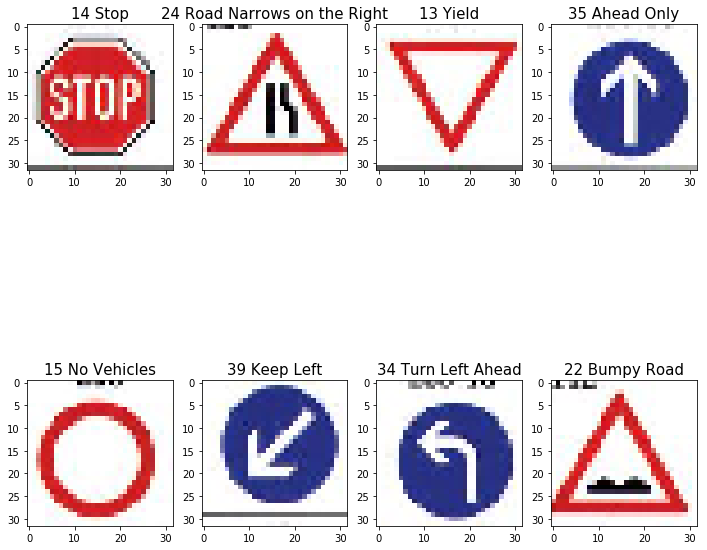

```python
X_web = np.zeros([8,32,32,3], dtype=float)
y_web = []
plt.figure(figsize=(12,12))

stopSignSection = signChart.crop((200,540,270,610)) #crop to the area of the sign
stopSign = stopSignSection.resize((32,32)) #resize the crop to 32x32
stopSignNp = np.asarray(stopSign)
for h in range(32):
    for w in range(32):
        X_web[0][h][w][0] = stopSignNp[h][w][0]
        X_web[0][h][w][1] = stopSignNp[h][w][1]
        X_web[0][h][w][2] = stopSignNp[h][w][2]
y_web.append(14) #label for stop sign
plt.subplot(2,4,1)
plt.imshow(stopSignNp)
plt.title('14 Stop', fontsize=15)

roadNarrowsOnTheRightSection = signChart.crop((112,237,182,307))
roadNarrowsOnTheRightSign = roadNarrowsOnTheRightSection.resize((32,32))
roadNarrowsOnTheRightSignNp = np.asarray(roadNarrowsOnTheRightSign)
for h in range(32):
    for w in range(32):
        X_web[1][h][w][0] = roadNarrowsOnTheRightSignNp[h][w][0]
        X_web[1][h][w][1] = roadNarrowsOnTheRightSignNp[h][w][1]
        X_web[1][h][w][2] = roadNarrowsOnTheRightSignNp[h][w][2]
y_web.append(24) #label for road narrows on the right sign
plt.subplot(2,4,2)
plt.imshow(roadNarrowsOnTheRightSignNp)
plt.title('24 Road Narrows on the Right', fontsize=15)

yieldSection = signChart.crop((112,540,182,610))
yieldSign = yieldSection.resize((32,32))
yieldSignNp = np.asarray(yieldSign)
for h in range(32):
    for w in range(32):
        X_web[2][h][w][0] = yieldSignNp[h][w][0]
        X_web[2][h][w][1] = yieldSignNp[h][w][1]
        X_web[2][h][w][2] = yieldSignNp[h][w][2]
y_web.append(13) #label for yield sign
plt.subplot(2,4,3)
plt.imshow(yieldSignNp)
plt.title('13 Yield', fontsize=15)

aheadOnlySection = signChart.crop((360,540,430,610))
aheadOnlySign = aheadOnlySection.resize((32,32))
aheadOnlySignNp = np.asarray(aheadOnlySign)
for h in range(32):
    for w in range(32):
        X_web[3][h][w][0] = aheadOnlySignNp[h][w][0]
        X_web[3][h][w][1] = aheadOnlySignNp[h][w][1]
        X_web[3][h][w][2] = aheadOnlySignNp[h][w][2]
y_web.append(35) #label for ahead only sign
plt.subplot(2,4,4)
plt.imshow(aheadOnlySignNp)
plt.title('35 Ahead Only', fontsize=15)

noVehiclesSection = signChart.crop((280,870,350,940))
noVehiclesSign = noVehiclesSection.resize((32,32))
noVehiclesSignNp = np.asarray(noVehiclesSign)
for h in range(32):
    for w in range(32):
        X_web[4][h][w][0] = noVehiclesSignNp[h][w][0]
        X_web[4][h][w][1] = noVehiclesSignNp[h][w][1]
        X_web[4][h][w][2] = noVehiclesSignNp[h][w][2]
y_web.append(15) #label for no vehicles sign
plt.subplot(2,4,5)
plt.imshow(noVehiclesSignNp)
plt.title('15 No Vehicles', fontsize=15)

keepLeftSection = signChart.crop((30,710,100,780))
keepLeftSign = keepLeftSection.resize((32,32))
keepLeftSignNp = np.asarray(keepLeftSign)
for h in range(32):
    for w in range(32):
        X_web[5][h][w][0] = keepLeftSignNp[h][w][0]
        X_web[5][h][w][1] = keepLeftSignNp[h][w][1]
        X_web[5][h][w][2] = keepLeftSignNp[h][w][2]
y_web.append(39) #label for keep left sign
plt.subplot(2,4,6)
plt.imshow(keepLeftSignNp)
plt.title('39 Keep Left', fontsize=15)

turnLeftAheadSection = signChart.crop((30,620,100,690))
turnLeftAheadSign = turnLeftAheadSection.resize((32,32))
turnLeftAheadSignNp = np.asarray(turnLeftAheadSign)
for h in range(32):
    for w in range(32):
        X_web[6][h][w][0] = turnLeftAheadSignNp[h][w][0]
        X_web[6][h][w][1] = turnLeftAheadSignNp[h][w][1]
        X_web[6][h][w][2] = turnLeftAheadSignNp[h][w][2]
y_web.append(34) #label for turn left ahead sign
plt.subplot(2,4,7)
plt.imshow(turnLeftAheadSignNp)
plt.title('34 Turn Left Ahead', fontsize=15)

bumpyRoadSection = signChart.crop((30,150,100,220))
bumpyRoadSign = bumpyRoadSection.resize((32,32))
bumpyRoadSignNp = np.asarray(bumpyRoadSign)
for h in range(32):
    for w in range(32):
        X_web[2][h][w][0] = bumpyRoadSignNp[h][w][0]
        X_web[2][h][w][1] = bumpyRoadSignNp[h][w][1]
        X_web[2][h][w][2] = bumpyRoadSignNp[h][w][2]
y_web.append(22) #label for bumpy road sign
plt.subplot(2,4,8)
plt.imshow(bumpyRoadSignNp)
plt.title('22 Bumpy Road', fontsize=15)
```

I pre-process these images:

```python
X_web_norm = RGBnorm(X_web)
```

I get the most recent trained model that I saved, then run the images through the model and save the logits.

The index of the highest logit is the predicted label.

```python
with tf.Session() as sess:
    sess.run(tf.global_variables_initializer())
    saver.restore(sess, tf.train.latest_checkpoint('.'))
    logitOutputs = sess.run(logits, feed_dict={x:X_web_norm, keep_prob:1.0})
    predictions = np.zeros(8, dtype=int)
    for i in range(8):
        prediction = np.argmax(logitOutputs[i])
        predictions[i] = prediction
        print('Prediction for first image {} is: {}'.format(i+1,prediction))
```

```
INFO:tensorflow:Restoring parameters from ./lenet
Prediction for first image 1 is: 14
Prediction for first image 2 is: 24
Prediction for first image 3 is: 22
Prediction for first image 4 is: 35
Prediction for first image 5 is: 15
Prediction for first image 6 is: 39
Prediction for first image 7 is: 34
Prediction for first image 8 is: 40
```

I compare the model's predictions to the correct labels and print the accuracy of my model against these images from the web.

```python
assert len(predictions) == len(y_web)
countCorrect=0
for i in range(predictions.shape[0]):
    if (predictions[i] == y_web[i]):
        countCorrect+=1
accuracy = countCorrect/predictions.shape[0]*100
print('Model accuracy on images from the web is {:.0f}%'.format(accuracy))
```

```
Model accuracy on images from the web is 75%
```

```python
with tf.Session() as sess:
    top5Prob = sess.run(tf.nn.top_k(tf.constant(logitOutputs), k=5))
```

```python
for i in range(len(X_web)):
    print('Prediction probabilities and labels for image {}'.format(i+1))
    print(top5Prob[0][i])
    print(top5Prob[1][i])
```

```
Prediction probabilities and labels for image 1
[ 21.18048286   8.43742275   2.82854295   2.19322538   0.44528478]
[14 17 29  3  1]
Prediction probabilities and labels for image 2
[ 42.21423721  40.11810684  32.29633331  12.82660484   9.6379528 ]
[24 18 27 21 26]
Prediction probabilities and labels for image 3
[ 28.60693741  10.45584106   5.9216466    3.18313694   1.77509356]
[22 29 26 15 25]
Prediction probabilities and labels for image 4
[ 38.7648201   14.66634178  12.89864635   7.50499153   3.77729774]
[35 33 34 36  3]
Prediction probabilities and labels for image 5
[ 24.42331696  10.61955166   7.44084787   4.0608263    3.4623723 ]
[15 13  2  1  9]
Prediction probabilities and labels for image 6
[ 14.57542801  10.16627407   7.03390837   1.20026922  -0.40139931]
[39 33 37 40  2]
Prediction probabilities and labels for image 7
[ 31.70986366  10.96602345  10.6237936    9.33525562   3.19660091]
[34 33 35 38  3]
Prediction probabilities and labels for image 8
[ 0.27933672  0.23081528  0.00694303 -0.13242954 -0.17441101]
[40 12  7  4 19]
```

This is to help visualize the logits calculated by the model. Below are the logits for the first image. You can see that the top 5 probabilities are in fact gathered in the data above.

```python
np.set_printoptions(threshold=np.inf)
logitOutputs[0]
```

```
array([ -7.0989399 ,   0.44528478,  -2.14855671,   2.19322538,
       -13.30731583,  -5.95251942, -14.8259182 , -16.55714035,
        -6.64331913,  -0.69736248,  -7.73920822,  -6.69651604,
       -10.77981853,  -4.38079453,  21.18048286,  -2.31398678,
       -16.75195503,   8.43742275,  -6.12062645, -12.15021133,
        -3.17557979,  -5.98546696,  -6.27515173,  -1.81018209,
       -14.0871582 ,  -0.90423816,  -2.96118331, -11.21937752,
        -5.74776363,   2.82854295,  -4.52737331,  -4.62621689,
        -5.00970364, -22.62815475, -11.78561592, -24.29925919,
       -16.08708763, -25.17591858, -11.19635201, -17.97577477,
       -24.65108299, -12.1709919 , -22.8540287 ], dtype=float32)
```

### Test using the provided test set

In addition to the training and validation sets which were used to train and test the model, there was a test set provided. Here I test my model against it.

```python
X_test_norm = RGBnorm(X_test_loaded)
```

The test set is evaluated and the accuracy displayed

```python
# find the accuracy of the complete test set.
with tf.Session() as sess:
    saver.restore(sess, tf.train.latest_checkpoint('.'))
    test_accuracy = evaluate(X_test_norm, y_test)
    print("Test Accuracy = {:.3f}".format(test_accuracy))
```

```
INFO:tensorflow:Restoring parameters from ./lenet
Test Accuracy = 0.942
```

## Step 4: Visualize the Neural Network's State with Test Images

```python
# image_input: the test image being fed into the network to produce the feature maps
# tf_activation: should be a tf variable name used during your training procedure that represents the calculated state of a specific weight layer
# activation_min/max: can be used to view the activation contrast in more detail, by default matplot sets min and max to the actual min and max values of the output
# plt_num: used to plot out multiple different weight feature map sets on the same block, just extend the plt number for each new feature map entry

def outputFeatureMap(image_input, tf_activation, activation_min=-1, activation_max=-1 ,plt_num=1):
    activation = tf_activation.eval(session=sess,feed_dict={x : image_input})
    featuremaps = activation.shape[3]
    plt.figure(plt_num, figsize=(15,15))
    for featuremap in range(featuremaps):
        plt.subplot(6,8, featuremap+1) # sets the number of feature maps to show on each row and column
        plt.title('FeatureMap ' + str(featuremap)) # displays the feature map number
        if activation_min != -1 & activation_max != -1:
            plt.imshow(activation[0,:,:, featuremap], interpolation="nearest", vmin =activation_min, vmax=activation_max, cmap="gray")
        elif activation_max != -1:
            plt.imshow(activation[0,:,:, featuremap], interpolation="nearest", vmax=activation_max, cmap="gray")
        elif activation_min !=-1:
            plt.imshow(activation[0,:,:, featuremap], interpolation="nearest", vmin=activation_min, cmap="gray")
        else:
            plt.imshow(activation[0,:,:, featuremap], interpolation="nearest", cmap="gray")
```

I have chosen to use the Keep Left sign that I got from the web as the image to evaluate. First, I have to change shape of image from (32,32,3) to (1,32,32,3) so it will match the size of the tensor x placeholder.

```python
keepLeftSignNp_norm = np.array([X_web_norm[5]])
```

```
INFO:tensorflow:Restoring parameters from ./lenet

Keep Left Sign Neural Network Layer 1, Weight Set 1
```

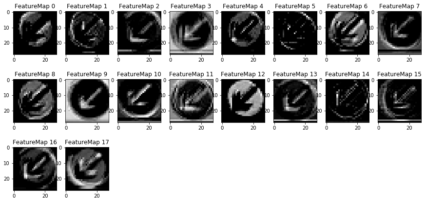

```python
with tf.Session() as sess:
    saver.restore(sess, tf.train.latest_checkpoint('.'))
    sess.run(tf.global_variables_initializer())
    print()
    print('Keep Left Sign Neural Network Layer 1, Weight Set 1')
    outputFeatureMap(keepLeftSignNp_norm, AL1, plt_num=1)
```

```
INFO:tensorflow:Restoring parameters from ./lenet

Keep Left Sign Neural Network Layer 1, Weight Set 10
```

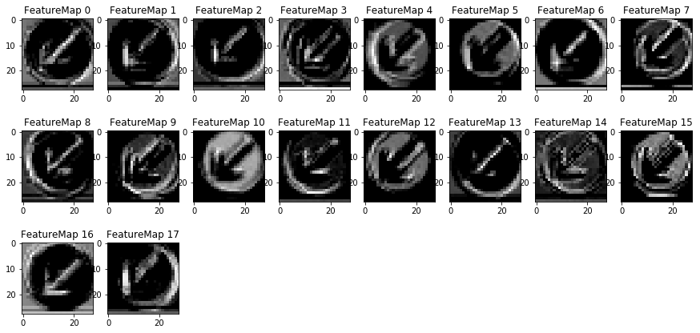

```python
with tf.Session() as sess:
    saver.restore(sess, tf.train.latest_checkpoint('.'))
    sess.run(tf.global_variables_initializer())
    print()
    print('Keep Left Sign Neural Network Layer 1, Weight Set 10')
    outputFeatureMap(keepLeftSignNp_norm, AL1, plt_num=10)
```

```
INFO:tensorflow:Restoring parameters from ./lenet

Keep Left Sign Neural Netowrk Layer 2, Weight Set 1
```

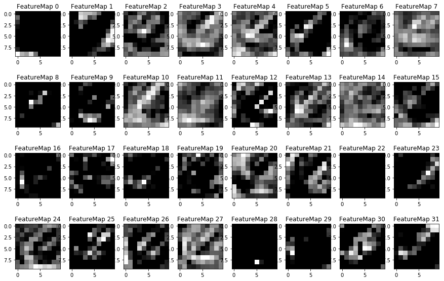

```python
with tf.Session() as sess:
    saver.restore(sess, tf.train.latest_checkpoint('.'))
    sess.run(tf.global_variables_initializer())
    print()
    print('Keep Left Sign Neural Netowrk Layer 2, Weight Set 1')
    outputFeatureMap(keepLeftSignNp_norm, AL2, plt_num=1)
```

```
INFO:tensorflow:Restoring parameters from ./lenet

Keep Left Sign Neural Netowrk Layer 2, Weight Set 10
```

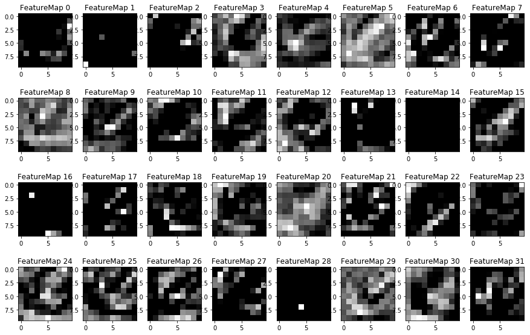

```python
with tf.Session() as sess:
    saver.restore(sess, tf.train.latest_checkpoint('.'))
    sess.run(tf.global_variables_initializer())
    print()
    print('Keep Left Sign Neural Netowrk Layer 2, Weight Set 10')
    outputFeatureMap(keepLeftSignNp_norm, AL2, plt_num=10)
```